# R Notebook

```r
library(readr)
library(stringr)
library(tidyverse)

code_clan_tweets <- read_csv("data/code_clan_tweets.csv")
nrow(code_clan_tweets)
```

```
[1] 234
```

```r
ncol(code_clan_tweets)
```

```
[1] 27
```

```r
dim(code_clan_tweets)
```

```
[1] 234  27
```

```r
names(code_clan_tweets)
```

```
 [1] "tweet_id"               "user_id"
 [3] "created_at"             "screen_name"
 [5] "text"                   "source"
 [7] "display_text_width"     "reply_to_status_id"
 [9] "reply_to_user_id"       "reply_to_screen_name"
[11] "is_quote"               "is_retweet"
[13] "favorite_count"         "retweet_count"
[15] "quote_count"            "reply_count"
[17] "hashtags"               "symbols"
[19] "urls_url"               "urls_t.co"
[21] "urls_expanded_url"      "media_type"
[23] "retweet_source"         "retweet_favorite_count"
[25] "retweet_retweet_count"  "retweet_user_id"
[27] "retweet_location"
```

```r
head (code_clan_tweets)
```

| tweet_id | user_id | created_at | screen_name | text | source | display_text_width | reply_to_status_id | reply_to_user_id | reply_to_screen_name | is_quote | is_retweet | favorite_count | retweet_count | quote_count | reply_count | hashtags | symbols | urls_url | urls_t.co | urls_expanded_url | media_type | retweet_source | retweet_favorite_count | retweet_retweet_count | retweet_user_id | retweet_location |
| --- | --- | --- | --- | --- | --- | --- | --- | --- | --- | --- | --- | --- | --- | --- | --- | --- | --- | --- | --- | --- | --- | --- | --- | --- | --- | --- |
| 347 | 3250721351 | 23/05/19 08:32 | CodeClanScot | @CodeClanScot has arrived in the Highlands! https://t.co/IJT6zbhEBT via @YouTube | Twitter Web App | 100 | NA | NA | NA | FALSE | TRUE | 0 | 1 | NA | NA | NA | NA | youtu.be/r3970XRMgeg | https://t.co/IJT6zbhEBT | https://youtu.be/r3970XRMgeg | NA | Twitter for iPhone | 5 | 1 | 1.110000e+18 | Edinburgh, Scotland |
| 346 | 3250721351 | 22/05/19 14:04 | CodeClanScot | We talked to one of our grads, Alex, about what it was like coming to CodeClan and changing career ___ Read her story here: https://t.co/UuFLgOFmcB | Twitter Web App | 148 | NA | NA | NA | FALSE | FALSE | 5 | 1 | NA | NA | NA | NA | bit.ly/2Hw8T1e | https://t.co/UuFLgOFmcB | https://bit.ly/2Hw8T1e | NA | NA | NA | NA | NA | NA |
| 345 | 3250721351 | 22/05/19 14:01 | CodeClanScot | A week to go until our #Dundee Sourcing the Next Generation of Talent event - have you booked your place yet? Come along to hear from @eplacementscot @GA_Dundee @CodeClanScot and @OUScotland on how th… | Twitter Web App | 140 | NA | NA | NA | FALSE | TRUE | 0 | 5 | NA | NA | Dundee | NA | NA | NA | NA | NA | Hootsuite Inc. | 6 | 5 | 3.997880e+07 | Scotland |
| 344 | 3250721351 | 22/05/19 13:22 | CodeClanScot | New #tech means new business opportunities. Join @IngledewStephen, @C_Leaver, @MaMChannel, @GerryMcCusker, @DonaldMcL, @pollyp + more at #DigitalScotland19 for some exciting chats around #skills &amp;… | Twitter Web App | 140 | NA | NA | NA | FALSE | TRUE | 0 | 4 | NA | NA | tech | NA | NA | NA | NA | NA | Twitter Web Client | 6 | 4 | 3.288078e+09 | Edinburgh, Scotland |
| 343 | 3250721351 | 22/05/19 10:10 | CodeClanScot | Scotland needs Data Analysts! Learn how you can gain the skills to transform your career at our Data Analysis Information Evening this Thursday. book your free ticket here: https://t.co/0UDZFQaGeB htt… | Twitter Web App | 196 | NA | NA | NA | FALSE | FALSE | 3 | 1 | NA | NA | NA | NA | bit.ly/2JUmdy0 | https://t.co/0UDZFQaGeB | http://bit.ly/2JUmdy0 | photo | NA | NA | NA | NA | NA |
| 342 | 3250721351 | 21/05/19 13:16 | CodeClanScot | RT @TechmumsHQ: Congrats to our Edinburgh #techmums on graduating and well done to the amazing @CodeClanScot facilitators for running such a brilliant #techmumsClub #digitalskillsmatter #empoweringwom… | Twitter Web App | 140 | NA | NA | NA | FALSE | TRUE | 0 | 3 | NA | NA | techmums | NA | NA | NA | NA | NA | IFTTT | 8 | 3 | 9.439170e+08 | Chicago, IL |

```r
tail(code_clan_tweets)
```

| tweet_id | user_id | created_at | screen_name | text | source | display_text_width | reply_to_status_id | reply_to_user_id | reply_to_screen_name | is_quote | is_retweet | favorite_count | retweet_count | quote_count | reply_count | hashtags | symbols | urls_url | urls_t.co | urls_expanded_url | media_type | retweet_source | retweet_favorite_count | retweet_retweet_count | retweet_user_id | retweet_location |
| --- | --- | --- | --- | --- | --- | --- | --- | --- | --- | --- | --- | --- | --- | --- | --- | --- | --- | --- | --- | --- | --- | --- | --- | --- | --- | --- |
| 119 | 3250721351 | 12/04/19 15:58 | CodeClanScot | Frances Maxwell, React/JS Developer at Skyscanner, came into our Glasgow campus today to tell our students about her experience! We're always looking for new speakers for our Industry Talks. Reach out… | Twitter Web App | 245 | NA | NA | NA | FALSE | FALSE | 7 | 2 | NA | NA | NA | NA | NA | NA | NA | photo | NA | NA | NA | NA | NA |
| 118 | 3250721351 | 12/04/19 11:45 | CodeClanScot | Huge thanks to @SwarmOnline for coming in to speak to our students today! https://t.co/FY4qS8fezU | Twitter for iPhone | 73 | NA | NA | NA | FALSE | FALSE | 3 | 3 | NA | NA | NA | NA | NA | NA | NA | photo | NA | NA | NA | NA | NA |
| 117 | 3250721351 | 11/04/19 15:36 | CodeClanScot | Scotland needs data analysts! Come to an info session this April and find out how our full-time course can launch you into a new career as an analyst, statistician, research analyst, and more. Book yo… | Twitter Web App | 280 | NA | NA | NA | FALSE | FALSE | 0 | 4 | NA | NA | NA | NA | bit.ly/2QuAUaU | https://t.co/LkU5V4xYrq | https://bit.ly/2QuAUaU | photo | NA | NA | NA | NA | NA |
| 116 | 3250721351 | 11/04/19 13:21 | CodeClanScot | Expand your team\xeas knowledge of R and help your business make more efficient decisions through data. Choose any or all of these one-day courses to quickly upskill your team this Spring: https://t.c… | Twitter Web App | 209 | NA | NA | NA | FALSE | FALSE | 1 | 2 | NA | NA | NA | NA | bit.ly/2DownoZ | https://t.co/cs3iuyoAqx | https://bit.ly/2DownoZ | photo | NA | NA | NA | NA | NA |
| 115 | 3250721351 | 10/04/19 17:30 | CodeClanScot | Part of what makes CodeClan what it is, is who we work with. Learn about some of the great charities and organisations we support and how they help bring more people into the world of tech! https://t.… | Hootsuite Inc. | 213 | NA | NA | NA | FALSE | FALSE | 1 | 1 | NA | NA | NA | NA | bit.ly/2U9NSwh | https://t.co/WziU7jYbWU | https://bit.ly/2U9NSwh | photo | NA | NA | NA | NA | NA |
| 114 | 3250721351 | 10/04/19 14:43 | CodeClanScot | Been with the awesome @TheHappyLass at @CodeClanScot today, and we were blown away: such cool people there and an amazing venue for our #WebVR workshops in #Glasgow! Thank you guys for being the offic… | Twitter Web App | 140 | NA | NA | NA | FALSE | TRUE | 0 | 2 | NA | NA | NA | NA | NA | NA | NA | NA | Twitter Web Client | 9 | 2 | 8.67e+17 | Edinburgh, UK |

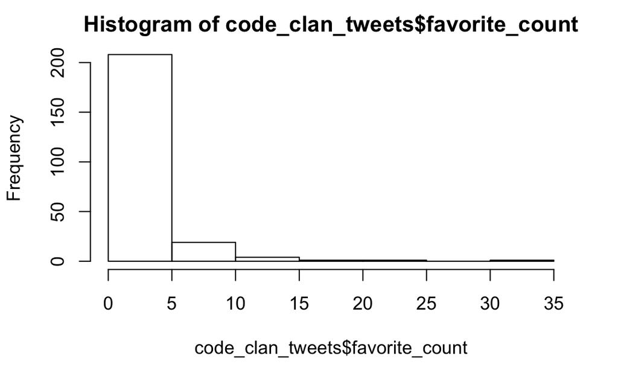

```r
hist(code_clan_tweets$favorite_count)
```

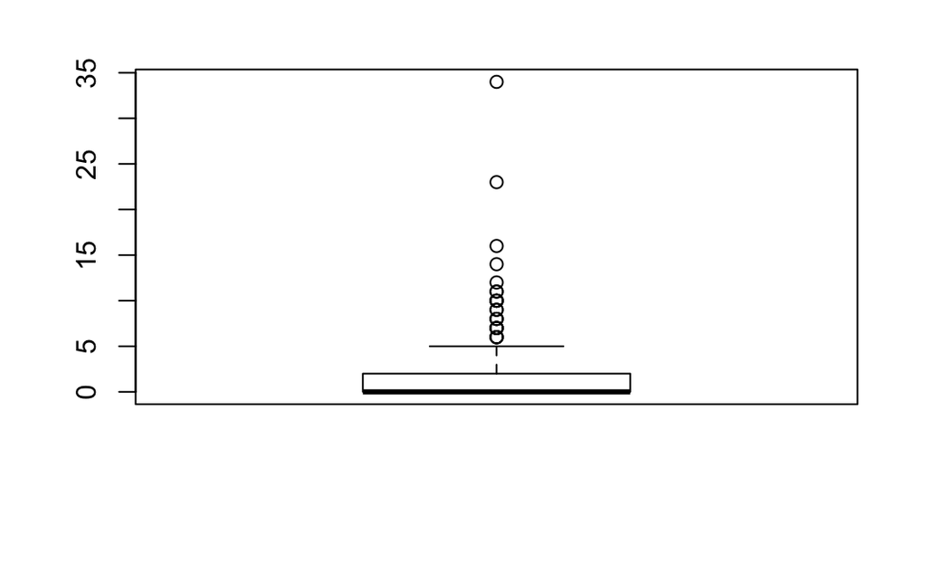

```r
boxplot(code_clan_tweets$favorite_count)
```

```r
summary(code_clan_tweets$favorite_count)
```

```
   Min. 1st Qu.  Median    Mean 3rd Qu.    Max.
  0.000   0.000   0.000   1.906   2.000  34.000
```

3.Find the total number of favourited tweets (stored in favorite_count) that CodeClan tweets have got. Don’t add a tweet’s favorite_count to the total when the tweet was quoted (see the is_quote variable).

```r
favourite_count_including_quote <- select(code_clan_tweets, is_quote, favorite_count)

count(favourite_count_including_quote)
```

| n |
| --- |
| 234 |

```r
total_favourite_tweet_excluding_quotes <- filter(favourite_count_including_quote, is_quote == "FALSE")
```

[output not shown]

```r
total_favourite_tweet_excluding_quotes
```

[output not shown]

Summarise the mean number of retweets (retweet_count), split by the type of platform that was used to tweet (source). Again, omit quoted tweets from the mean.

```r
data_omoying_quoted_tweets <- filter(code_clan_tweets, is_quote =="False")

mean(code_clan_tweets$retweet_count)

group_by(data_omoying_quoted_tweets)

data_omoying_quoted_tweets
```

[output not shown]

Count the total number of likes (i.e. total of favorite_count), split by media type, and arrange them from most likes to least. Assume that any tweets without a listed media type are of type “text”.

6.Find the mean number of characters that a CodeClan tweet contains

```r
mean(code_clan_tweets$display_text_width)
```

```
[1] 149.4188
```

7.The code_clan_info.csv data file contains status_url along with other info. Load this in, and join it to the code_clan_tweets tibble, so that you have a status_url for each tweet. Decide which variable to join the tibbles on.

```r
code_clan_info <- read_csv("data/code_clan_info.csv")
```

```r
code_clan_info

nrow(code_clan_info)

ncol(code_clan_info)

dim(code_clan_info)

names(code_clan_info)

head (code_clan_info)
```

[output not shown]

```r
code_clan_tweets_info <- full_join(code_clan_tweets, code_clan_info, by ="tweet_id")

code_clan_tweets_info
```

[output not shown]

8.From your new joined data, create a new tibble codeclan_hashtags containing only the tweet_id and hashtags in lowercase for analysis. Keep only those tweets with hashtags

```r
# step one by using the mutate function,change all the text to lower case,
# step two select only the tweets which have the "# "spevial character in them


codeclan_hashtags <- select(code_clan_tweets_info$tweet_id,"text == # ")
```